# Knapp, Stephen

## Deep Learning Assignment 9

```python
import numpy as np
import gensim
# Get the interactive Tools for Matplotlib
import matplotlib
import matplotlib.pyplot as plt
%matplotlib inline
from sklearn.decomposition import PCA
from sklearn.manifold import TSNE
from gensim.test.utils import datapath, get_tmpfile
from gensim.models import KeyedVectors
from gensim.scripts.glove2word2vec import glove2word2vec
import spacy
from spacy.lang.en import English
```

```python
from google.colab import drive
drive.mount('/content/drive')
```

```
Go to this URL in a browser: https://accounts.google.com/o/oauth2/auth?client_id=947318989803-6bn6qk8qdgf4n4g3pfee6491hc0brc4i.apps.googleusercontent.com&redirect_uri=urn%3aietf%3awg%3aoauth%3a2.0%3aoob&response_type=code&scope=email%20https%3a%2f%2fwww.googleapis.com%2fauth%2fdocs.test%20https%3a%2…

Enter your authorization code:
··········
```

## Problem 1

Cygwin code:

$ make $ time ./word2vec -train text8 -output vectors.bin -cbow 1 -size 300 -window 8 -negative 25 -hs 0 -sample 1e-4 -threads 20 -binary 0 -iter 15 Starting training using file text8 Vocab size: 71291 Words in train file: 16718843 Alpha: 0.000005 Progress: 100.10% Words/thread/sec: 40.90k real 15m55.780s user 104m50.421s sys 0m6.765s $ ./word-analogy.exe GoogleNews-vectors-negative300.bin Enter three words (EXIT to break): france paris russia

Word: france Position in vocabulary: 225534

Word: paris Position in vocabulary: 198365

Word: russia Position in vocabulary: 294451

```
                                          Word              Distance
```

```
                                   north_korea              0.471760
                                    tom_cruise              0.449580
                                         lohan              0.448753
                                          joel              0.445634
                                 lindsay_lohan              0.445479
                                         heidi              0.440514
                                     megan_fox              0.438607
                                       britney              0.429737
                                      russians              0.429316
                                        moscow              0.428812
                               natalie_portman              0.426762
                                       lil_kim              0.425724
                                       rihanna              0.425628
                                       lindsay              0.420228
                                      thailand              0.419693
                                           wiv              0.417865
                                        jessie              0.417515
                                 nicole_richie              0.417459
                                       lindsey              0.417458
                                     alexandra              0.416858
                                     christina              0.415890
                                       whitney              0.415334
                                  paris_hilton              0.415204
                                     brad_pitt              0.413550
                                        monica              0.412652
                                           tmz              0.411524
                                         paula              0.410811
                                          gwen              0.409483
                                 charlie_sheen              0.409303
                                        hilton              0.409228
                                 washington_dc              0.408328
                                        ronnie              0.407938
                                         nikki              0.407641
                                       ukraine              0.407487
                                       natalie              0.406954
                                   barbie_doll              0.406901
                                       michele              0.406771
                                angelina_jolie              0.406008
                                          ktla              0.405925
                              jennifer_aniston              0.404747
```

Enter three words (EXIT to break): USA washington_dc UK

Word: USA Position in vocabulary: 2276

Word: washington_dc Position in vocabulary: 840882

Word: UK Position in vocabulary: 928

```
                                          Word              Distance
```

```
                                         tesco              0.492387
                                      scotland              0.487275
                                  gordon_brown              0.486360
                                       british              0.486181
                                       britain              0.473281
                                   westminster              0.470460
                                        london              0.468258
                                      barclays              0.458864
                                    washington              0.456587
                                            uk              0.451748
                                      tasmania              0.448211
                                      somerset              0.447870
                                         malta              0.444047
                              northern_ireland              0.443387
                                        Heddlu              0.440386
                                           UKs              0.439778
                                       russell              0.439609
                                            Uk              0.438327
                                   Fylde_coast              0.436810
                                   £_6billion               0.431206
                               lehman_brothers              0.430657
                                   albuquerque              0.430636
                                    australian              0.430463
                                         essex              0.428367
                                     taj_mahal              0.427947
                                           wot              0.424913
                                         adams              0.424050
                                        europe              0.424024
                                 Francis_Maude              0.423974
                                     blackpool              0.423024
                                       el_paso              0.422961
                                         devon              0.422773
                                          dodd              0.422234
                                      ron_paul              0.422220
                                     sri_lanka              0.422184
                                     XXXXXXing              0.421631
                                       £_###k               0.420904
                                         iraqi              0.420791
                                       belfast              0.420452
                                           hev              0.420234
```

Enter three words (EXIT to break): china beijing italy

Word: china Position in vocabulary: 32952

Word: beijing Position in vocabulary: 537874

Word: italy Position in vocabulary: 283535

```
                                          Word              Distance
```

```
                                     barcelona              0.566662
                                         diego              0.534301
                                         spain              0.525933
                                      montreal              0.510384
                                        sweden              0.509806
                                   real_madrid              0.504179
                                       orlando              0.502051
                                   inter_milan              0.501926
                                       croatia              0.500982
                                          juve              0.499925
                                       ronaldo              0.493477
                                          luis              0.493169
                                        lebron              0.491013
                                      ac_milan              0.490685
                                        europe              0.489157
                                        france              0.488852
                                        madrid              0.488293
                                           epl              0.488080
                                         forza              0.486562
                                          lyon              0.485370
                                        bayern              0.482659
                                        milano              0.482116
                                    santa_cruz              0.481644
                                         malta              0.480842
                                        carlos              0.480308
                                         perth              0.480103
                                     argentina              0.479513
                                       italian              0.478078
                                        zidane              0.477602
                                      italians              0.475284
                                        athens              0.474737
                                           usa              0.474526
                                    portuguese              0.473479
                                         eto'o              0.472582
                                       minutos              0.472089
                                      portugal              0.471547
                                       ireland              0.471434
                                     liverpool              0.471409
                                       holland              0.471090
                                        greece              0.469304
```

Enter three words (EXIT to break): Canada ottawa spain

Word: Canada Position in vocabulary: 732

Word: ottawa Position in vocabulary: 572391

Word: spain Position in vocabulary: 261628

```
                                          Word              Distance
```

```
                                        madrid              0.646454
                                        carlos              0.641303
                                       sanchez              0.632822
                                      valencia              0.616917
                                          alex              0.609036
                                      florence              0.605642
                                         diego              0.603246
                                      martinez              0.600520
                                      thompson              0.598823
                                       holland              0.597541
                                          luis              0.595870
                                     barcelona              0.593049
                                      williams              0.590833
                                         ramos              0.590415
                                        thomas              0.587581
                                       gilbert              0.587537
                                          raul              0.586900
                                          lyon              0.586287
                                          juan              0.585569
                                     hernandez              0.583346
                                    birmingham              0.583141
                                          dunn              0.582263
                                      columbia              0.582214
                                          jose              0.581086
                                        samuel              0.581084
                                       orlando              0.580889
                                            os              0.580558
                                        athens              0.580102
                                        miguel              0.580005
                                       rosario              0.579041
                                        joseph              0.578241
                                        bolton              0.575849
                                         marco              0.575431
                                    portsmouth              0.574388
                                        jacobs              0.572217
                                        walton              0.572086
                                         perez              0.571837
                                        arthur              0.570803
                                         eddie              0.570745
                                        torres              0.570596
```

Modified demo-word.sh file:

make if [ ! -e text8 ]; then wget http://mattmahoney.net/dc/text8.zip -O text8.gz gzip -d text8.gz -f fi time ./word2vec -train text8 -output vectors.txt -cbow 1 -size 300 -window 8 -negative 25 -hs 0 -sample 1e-4 -threads 20 -binary 0 -iter 15 ./distance vectors.bin

Cygwin code:

$./demo-word.sh

## Problem 2

```python
glove_file = 'drive/My Drive/Colab Notebooks/glove.6B.100d.txt'
word2vec_glove_file = get_tmpfile("glove.6B.100d.word2vec.txt")
glove2word2vec(glove_file, word2vec_glove_file)
```

```
(400000, 100)
```

```python
model = KeyedVectors.load_word2vec_format(word2vec_glove_file)
```

```python
capitals = ['canada', 'ottawa', 'spain', 'madrid', 'france', 'paris', 'russia', 'moscow',
         'usa', 'washington', 'uk', 'london', 'china', 'beijing', 'italy', 'rome']
```

```python
words = capitals
```

```python
word_vectors = np.array([model[w] for w in words])
twodim = PCA().fit_transform(word_vectors)[:,:2]
```

```python
def divide_chunks(l, n):

    # looping till length l
    for i in range(0, len(l), n):
        yield l[i:i + n]

# How many elements each
# list should have
n = 2
```

```python
twodimpoints = list(divide_chunks(twodim, n))
```

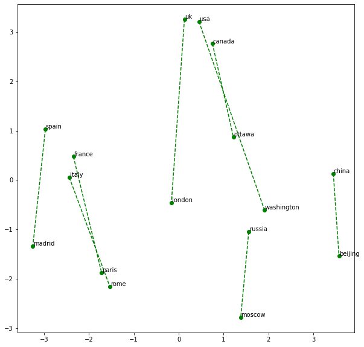

```python
pairs=len(words)/2
i=0
j=0
plt.figure(figsize=(10,10))
while i < pairs:
  plt.plot([twodimpoints[i][0,0], twodimpoints[i][1,0]], [twodimpoints[i][0,1], twodimpoints[i][1,1]], 'go--')
  plt.text(twodimpoints[i][0,0]+0.01, twodimpoints[i][0,1]+0.01, words[j])
  plt.text(twodimpoints[i][1,0]+0.01, twodimpoints[i][1,1]+0.01, words[j+1])
  j = j + 2
  i = i + 1;
plt.show();
```

The lines are relatively parallel to each other. For each the country is the higher points and the capital is the lower points. The lines range from approximately -75 to -105 degrees (relative to the country point).

```python
relatives = ['father', 'son', 'mother', 'daughter', 'grandmother', 'granddaughter', 'grandfather', 'grandson',
         'uncle', 'nephew', 'aunt', 'niece']
```

```python
words = relatives
```

```python
word_vectors = np.array([model[w] for w in words])
twodim = PCA().fit_transform(word_vectors)[:,:2]
```

```python
twodimpoints = list(divide_chunks(twodim, n))
```

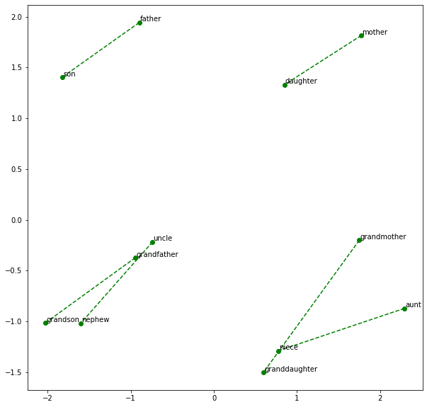

```python
pairs=len(words)/2
i=0
j=0
plt.figure(figsize=(10,10))
while i < pairs:
  plt.plot([twodimpoints[i][0,0], twodimpoints[i][1,0]], [twodimpoints[i][0,1], twodimpoints[i][1,1]], 'go--')
  plt.text(twodimpoints[i][0,0]+0.01, twodimpoints[i][0,1]+0.01, words[j])
  plt.text(twodimpoints[i][1,0]+0.01, twodimpoints[i][1,1]+0.01, words[j+1])
  j = j + 2
  i = i + 1;
plt.show();
```

Here we see again almost parallel lines. The older person's title is higher and to the right of the younger person's title. The lines vary from approximately 30 to 45 degrees (from the younger title to the older).

## Problem 3

```python
glove_file = 'drive/My Drive/Colab Notebooks/glove.6B.300d.txt'
word2vec_glove_file = get_tmpfile("glove.6B.300d.word2vec.txt")
glove2word2vec(glove_file, word2vec_glove_file)
```

```
(400000, 300)
```

```python
model = KeyedVectors.load_word2vec_format(word2vec_glove_file, limit=143488, unicode_errors='ignore')
```

```python
words = capitals
```

```python
word_vectors = np.array([model[w] for w in words])
twodim = PCA().fit_transform(word_vectors)[:,:2]
```

```python
twodimpoints = list(divide_chunks(twodim, n))
```

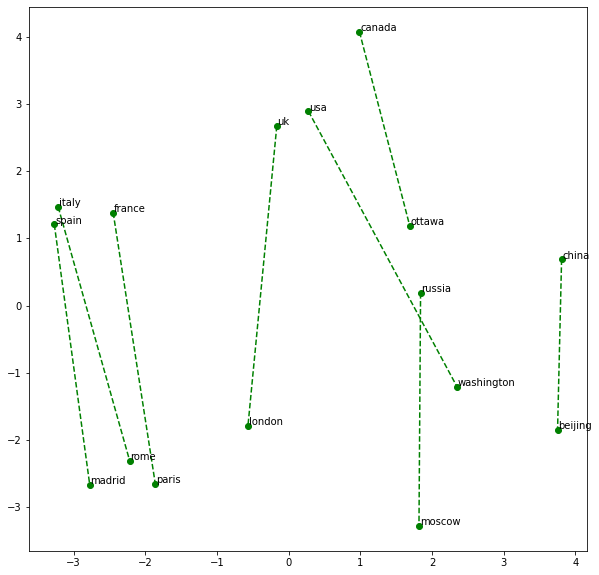

```python
pairs=len(words)/2
i=0
j=0
plt.figure(figsize=(10,10))
while i < pairs:
  plt.plot([twodimpoints[i][0,0], twodimpoints[i][1,0]], [twodimpoints[i][0,1], twodimpoints[i][1,1]], 'go--')
  plt.text(twodimpoints[i][0,0]+0.01, twodimpoints[i][0,1]+0.01, words[j])
  plt.text(twodimpoints[i][1,0]+0.01, twodimpoints[i][1,1]+0.01, words[j+1])
  j = j + 2
  i = i + 1;
plt.show();
```

Using the 300 dimensional vector we see much more parallelism between the lines.

```python
words = relatives
```

```python
word_vectors = np.array([model[w] for w in words])
twodim = PCA().fit_transform(word_vectors)[:,:2]
```

```python
twodimpoints = list(divide_chunks(twodim, n))
```

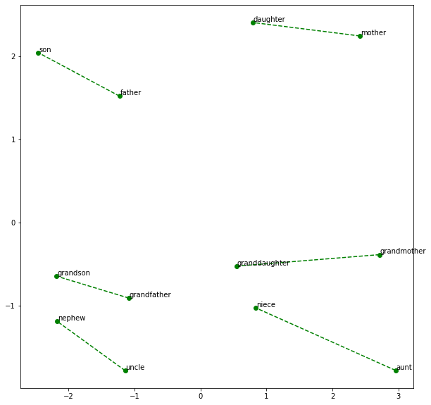

```python
pairs=len(words)/2
i=0
j=0
plt.figure(figsize=(10,10))
while i < pairs:
  plt.plot([twodimpoints[i][0,0], twodimpoints[i][1,0]], [twodimpoints[i][0,1], twodimpoints[i][1,1]], 'go--')
  plt.text(twodimpoints[i][0,0]+0.01, twodimpoints[i][0,1]+0.01, words[j])
  plt.text(twodimpoints[i][1,0]+0.01, twodimpoints[i][1,1]+0.01, words[j+1])
  j = j + 2
  i = i + 1;
plt.show();
```

In this case the results look very similar to using the 100 dimensional vector with respect to parallelism between the lines.

## Problem 4

```python
words = capitals
```

```python
word_vectors = np.array([model[w] for w in words])
```

```python
X_embedded = TSNE(n_components=2, perplexity=50.0).fit_transform(word_vectors)
```

```python
twodimpoints = list(divide_chunks(X_embedded, n))
```

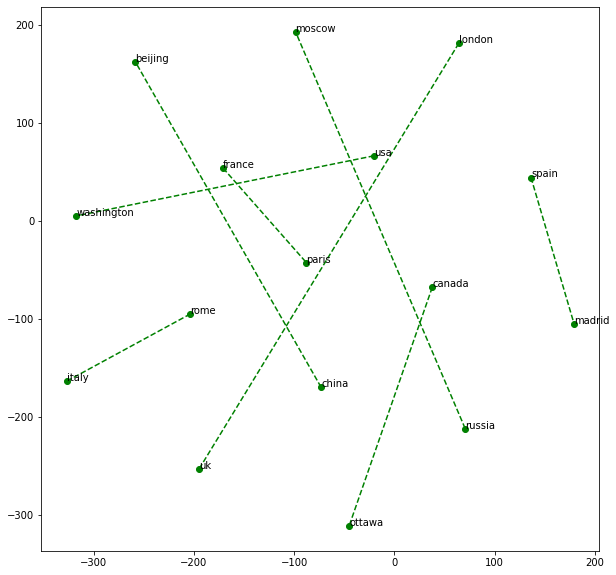

```python
pairs=len(words)/2
i=0
j=0
plt.figure(figsize=(10,10))
while i < pairs:
  plt.plot([twodimpoints[i][0,0], twodimpoints[i][1,0]], [twodimpoints[i][0,1], twodimpoints[i][1,1]], 'go--')
  plt.text(twodimpoints[i][0,0]+0.01, twodimpoints[i][0,1]+0.01, words[j])
  plt.text(twodimpoints[i][1,0]+0.01, twodimpoints[i][1,1]+0.01, words[j+1])
  j = j + 2
  i = i + 1;
plt.show();
```

The parallelization pattern is almost non-existent despite trying a range of perplexities from 5 to 300.

```python
words = relatives
```

```python
word_vectors = np.array([model[w] for w in words])
X_embedded = TSNE(n_components=2).fit_transform(word_vectors)
```

```python
twodimpoints = list(divide_chunks(X_embedded, n))
```

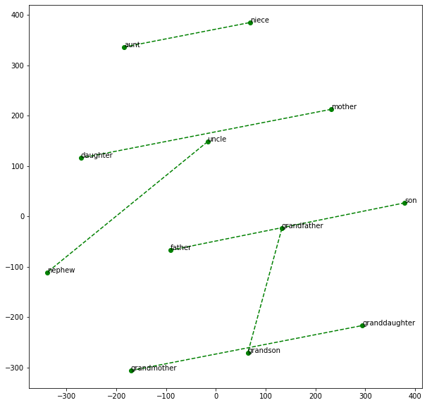

```python
pairs=len(words)/2
i=0
j=0
plt.figure(figsize=(10,10))
while i < pairs:
  plt.plot([twodimpoints[i][0,0], twodimpoints[i][1,0]], [twodimpoints[i][0,1], twodimpoints[i][1,1]], 'go--')
  plt.text(twodimpoints[i][0,0]+0.01, twodimpoints[i][0,1]+0.01, words[j])
  plt.text(twodimpoints[i][1,0]+0.01, twodimpoints[i][1,1]+0.01, words[j+1])
  j = j + 2
  i = i + 1;
plt.show();
```

Here we see strong parallelism between 4 of the relationships but then the other two are almost perpendicular to them. There is much less of an obvious relationship using the T-SNE method.

## Problem 5

```python
#set parser to english
parser = spacy.load('en')
#load the model
nlp = spacy.load("en_core_web_sm")
```

```python
#define word bank
words = capitals
```

```python
#turn word strings into arrays
word_vectors = [nlp(w).vector for w in words]
#analyze relative distances between words using PCA
twodim = PCA().fit_transform(word_vectors)[:,:2]
```

```python
#chunk locations into word pairs
twodimpoints = list(divide_chunks(twodim, n))
```

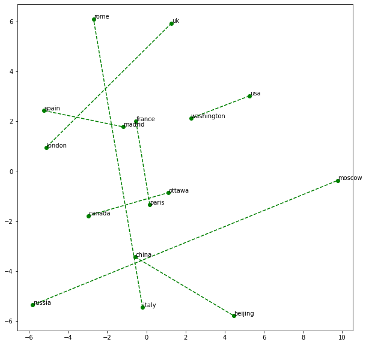

```python
#set number of word pairs
pairs=len(words)/2
#initialize counter for words
i=0
#initialize counter for word pairs
j=0
#provide plotting canvas
plt.figure(figsize=(10,10))
#while loop to plot all pairs and draw lines
while i < pairs:
  #plot a pair with line connecting
  plt.plot([twodimpoints[i][0,0], twodimpoints[i][1,0]], [twodimpoints[i][0,1], twodimpoints[i][1,1]], 'go--')
  #add point labels
  plt.text(twodimpoints[i][0,0]+0.01, twodimpoints[i][0,1]+0.01, words[j])
  plt.text(twodimpoints[i][1,0]+0.01, twodimpoints[i][1,1]+0.01, words[j+1])
  #advance both counters
  j = j + 2
  i = i + 1;
#now show the plot
plt.show();
```

There is essentially no descernable parallel pattern.

```python
#define word bank
words = relatives
```

```python
#turn word strings into arrays
word_vectors = [nlp(w).vector for w in words]
#analyze relative distances between words using PCA
twodim = PCA().fit_transform(word_vectors)[:,:2]
```

```python
#chunk locations into word pairs
twodimpoints = list(divide_chunks(twodim, n))
```

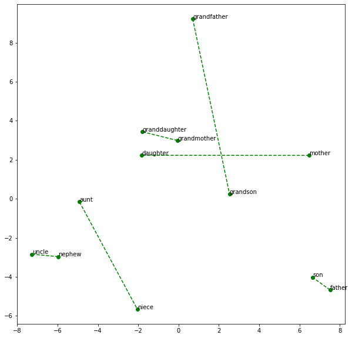

```python
#set number of word pairs
pairs=len(words)/2
#initialize counter for words
i=0
#initialize counter for word pairs
j=0
#provide plotting canvas
plt.figure(figsize=(10,10))
#while loop to plot all pairs and draw lines
while i < pairs:
  #plot a pair with line connecting
  plt.plot([twodimpoints[i][0,0], twodimpoints[i][1,0]], [twodimpoints[i][0,1], twodimpoints[i][1,1]], 'go--')
  #add point labels
  plt.text(twodimpoints[i][0,0]+0.01, twodimpoints[i][0,1]+0.01, words[j])
  plt.text(twodimpoints[i][1,0]+0.01, twodimpoints[i][1,1]+0.01, words[j+1])
  #advance both counters
  j = j + 2
  i = i + 1;
#now show the plot
plt.show();
```

There is no discernable parallel pattern using the small model.

```python
#download model
!python -m spacy download en_vectors_web_lg
```

```
     |████████████████████████████████| 661.8MB 1.1MB/s
✔ Download and installation successful
You can now load the model via spacy.load('en_vectors_web_lg')
```

```python
!python -m spacy download en
```

```
✔ Download and installation successful
You can now load the model via spacy.load('en_core_web_sm')
✔ Linking successful
/usr/local/lib/python3.6/dist-packages/en_core_web_sm -->
/usr/local/lib/python3.6/dist-packages/spacy/data/en
You can now load the model via spacy.load('en')
```

```python
#define the model
nlp = en_vectors_web_lg.load()
```

```python
#define word bank
words = capitals
```

```python
#turn word strings into arrays
word_vectors = [nlp(w).vector for w in words]
#analyze relative distances between words using PCA
twodim = PCA().fit_transform(word_vectors)[:,:2]
```

```python
#chunk locations into word pairs
twodimpoints = list(divide_chunks(twodim, n))
```

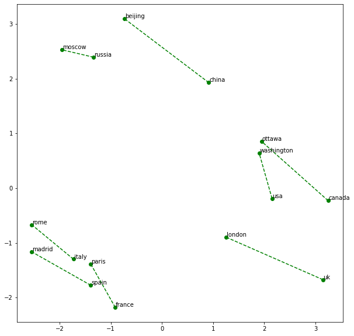

```python
#set number of word pairs
pairs=len(words)/2
#initialize counter for words
i=0
#initialize counter for word pairs
j=0
#provide plotting canvas
plt.figure(figsize=(10,10))
#while loop to plot all pairs and draw lines
while i < pairs:
  #plot a pair with line connecting
  plt.plot([twodimpoints[i][0,0], twodimpoints[i][1,0]], [twodimpoints[i][0,1], twodimpoints[i][1,1]], 'go--')
  #add point labels
  plt.text(twodimpoints[i][0,0]+0.01, twodimpoints[i][0,1]+0.01, words[j])
  plt.text(twodimpoints[i][1,0]+0.01, twodimpoints[i][1,1]+0.01, words[j+1])
  #advance both counters
  j = j + 2
  i = i + 1;
#now show the plot
plt.show();
```

Using the larger model we see much more parallelism. There also appears to be possible grouping based on geography and possibly language.

```python
#define word bank
words = relatives
```

```python
#turn word strings into arrays
word_vectors = [nlp(w).vector for w in words]
#analyze relative distances between words using PCA
twodim = PCA().fit_transform(word_vectors)[:,:2]
```

```python
#chunk locations into word pairs
twodimpoints = list(divide_chunks(twodim, n))
```

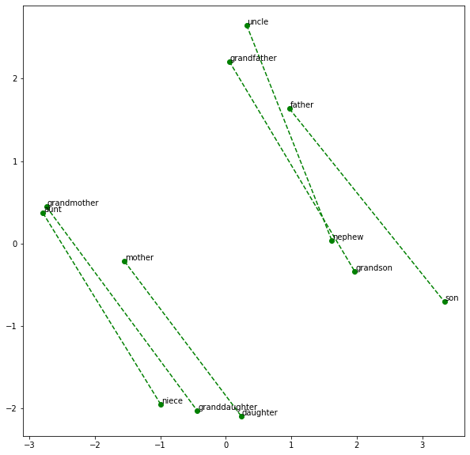

```python
#set number of word pairs
pairs=len(words)/2
#initialize counter for words
i=0
#initialize counter for word pairs
j=0
#provide plotting canvas
plt.figure(figsize=(10,10))
#while loop to plot all pairs and draw lines
while i < pairs:
  #plot a pair with line connecting
  plt.plot([twodimpoints[i][0,0], twodimpoints[i][1,0]], [twodimpoints[i][0,1], twodimpoints[i][1,1]], 'go--')
  #add point labels
  plt.text(twodimpoints[i][0,0]+0.01, twodimpoints[i][0,1]+0.01, words[j])
  plt.text(twodimpoints[i][1,0]+0.01, twodimpoints[i][1,1]+0.01, words[j+1])
  #advance both counters
  j = j + 2
  i = i + 1;
#now show the plot
plt.show();
```

We see significant parallelism using the larger model. It also grouped by gender too.

This model appears to be superior to all previous models used.